# Data Analytics Mini Project.

By Akshay Kumar Dhage (4NI17IS009) and Ashish MJ (4NI17IS017).

# Heart Disease Detection.

## Introduction

The mini project “Heart Disease Detection” basically focuses on data analysis and making predictions based on the analysis using machine learning. Performing data analysis on people’s medical data with respect to heart health can help in finding insights and correlation of various factors with the heart health of an individual. The analysis shall be a great help in the medical industry which shall help in further improvements. Based on the analysis predictions shall be made to detect the presence of heart disease by using machine learning.

For the analysis, we are using Python programming language, as it supports all the required modern libraries to perform analysis.

Dataset overview,

Age - age in years

Sex - (1 = male; 0 = female)

Cp - chest pain type

Trestbps - resting blood pressure (in mm Hg on admission to the hospital)

Chol - serum cholesterol in mg/dl

Fbs - (fasting blood sugar > 120 mg/dl) (1 = true; 0 = false)

Restecg - resting electrocardiographic results

Thalach - maximum heart rate achieved

Exang - exercise induced angina (1 = yes; 0 = no)

Oldpeak - ST depression induced by exercise relative to rest

Slope - the slope of the peak exercise ST segment

Target – 1 (presence of heart disease) or 0 (no presence)

Here Target variable indicates the presence or absence of heart disease hence is classification objective, and we require to predict Target variable.

## 1. Data Analysis

## 1.1. Importing python libraries.

```python
import pandas as pd
import numpy as np
import matplotlib.pyplot as plt
import seaborn as sns

%matplotlib inline

import warnings
warnings.filterwarnings('ignore')
```

## 1.2. Reading and viewing Data Set in CSV format.

“df.head()” views first five data rows present in the dataset. Data set consists of total of 303 rows and 14 features including target.

```python
df=pd.read_csv("heart.csv")
```

```python
df.head()
```

|  | age | sex | cp | trestbps | chol | fbs | restecg | thalach | exang | oldpeak | slope | ca | thal | target |
| --- | --- | --- | --- | --- | --- | --- | --- | --- | --- | --- | --- | --- | --- | --- |
| 0 | 63 | 1 | 3 | 145 | 233 | 1 | 0 | 150 | 0 | 2.3 | 0 | 0 | 1 | 1 |
| 1 | 37 | 1 | 2 | 130 | 250 | 0 | 1 | 187 | 0 | 3.5 | 0 | 0 | 2 | 1 |
| 2 | 41 | 0 | 1 | 130 | 204 | 0 | 0 | 172 | 0 | 1.4 | 2 | 0 | 2 | 1 |
| 3 | 56 | 1 | 1 | 120 | 236 | 0 | 1 | 178 | 0 | 0.8 | 2 | 0 | 2 | 1 |
| 4 | 57 | 0 | 0 | 120 | 354 | 0 | 1 | 163 | 1 | 0.6 | 2 | 0 | 2 | 1 |

## 1.3. Data Munging by Exploratory Data Analysis.

## 1.3. Data Visualisation

## I. Available Age group diversity in dataset.

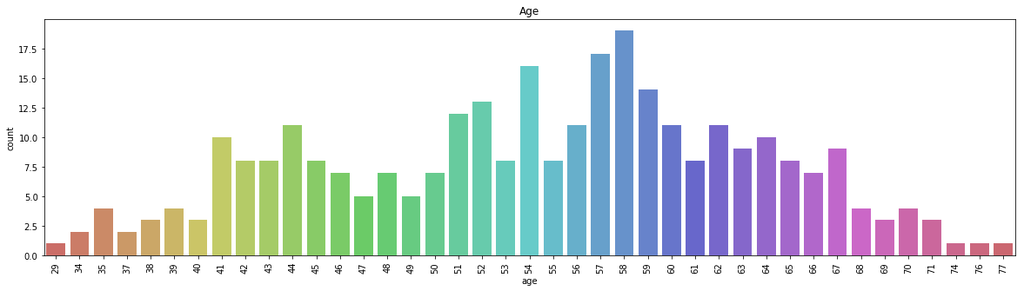

```python
plt.figure(figsize=(20,5))
fig = sns.countplot(x=df['age'], palette="hls")
fig.set_xticklabels(fig.get_xticklabels(),rotation=90)
plt.title('Age')
plt.show(fig)
```

From the above age graph, we can analyse that our dataset consists of data of various age group individuals ranging from age 29 to age 77.

## II. Sex group diversity in dataset.

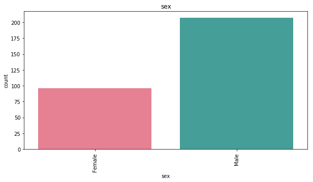

```python
plt.figure(figsize=(10,5))
fig = sns.countplot(x=df['sex'], palette="husl")
fig.set_xticklabels(['Female', 'Male'],rotation=90)
plt.title('sex')
plt.show(fig)
```

Data consists of ~100 Female individuals and ~200 Male individuals.

## III. Diversity of presence of Heart disease.

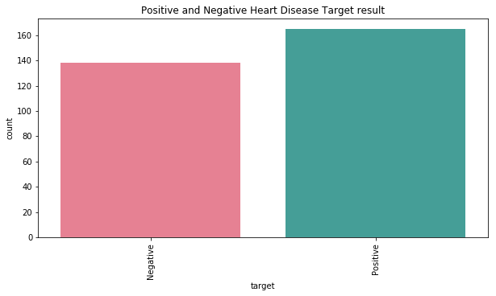

```python
#0: Negative, 1: Positive
plt.figure(figsize=(10,5))
fig = sns.countplot(x=df['target'], palette="husl")
fig.set_xticklabels(['Negative', 'Positive'],rotation=90)
plt.title('Positive and Negative Heart Disease Target result')
plt.show(fig)
```

Negative implies absence of heart disease. Positive implies presence of heart disease.

We can see that our data is balanced in terms of the target or balanced amount of data of individuals having heart disease and those who are healthy is present. It shall help in avoiding a biased decision/prediction towards any of the two outcomes.

## IV. Diversity of Blood Pressure Values.

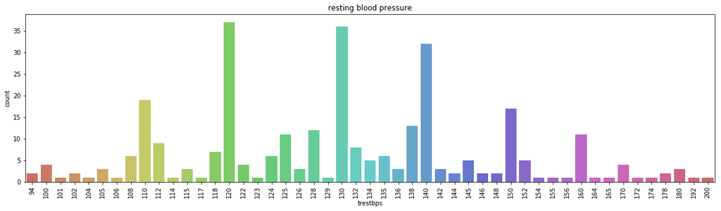

```python
plt.figure(figsize=(20,5))
fig = sns.countplot(x=df['trestbps'], palette="hls")
fig.set_xticklabels(fig.get_xticklabels(),rotation=90)
plt.title('resting blood pressure')
plt.show(fig)
```

Blood Pressure value ranges from 94 value to 200 value and is distributed along this range. Majority BP value is 120 followed by 130 and 140 value.

## V. Correlation of feature variables with the target variable(result).

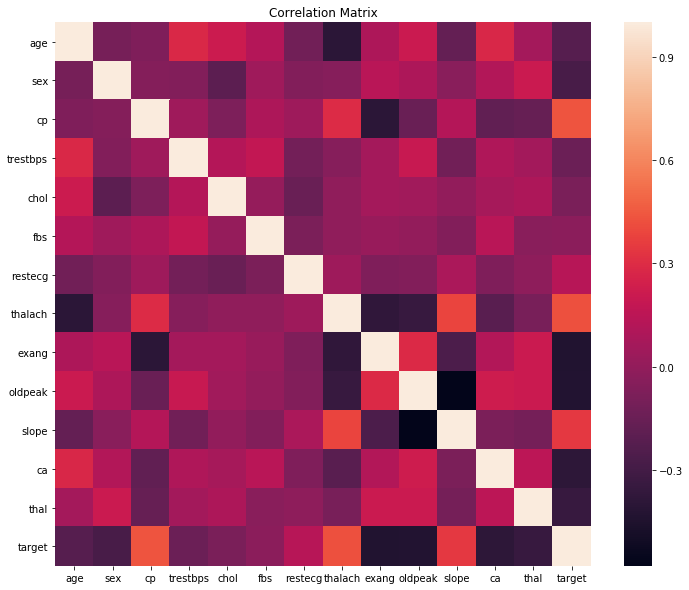

```python
plt.figure(figsize=(12, 10))
sns.heatmap(df.corr())
plt.title('Correlation Matrix')
plt.show()
```

We can see that target variable strongly depends on “cp” (chest pain type) feature variable, followed by “thalach”(max heart rate) variable, and “slope” variable.

## 1.4. Data Pre-processing

## I. Encoding on feature variables/Feature selection.

For better model training, we shall use dummy encoding method for pre-processing before using the data for training machine learning model.

Dummy Encoding (Boolean Indicator), we shall create new variables with each of the possible values as a column and having 1 as the value for a particular column and rest columns as 0.

```python
#data preprocessing for categorical features
from sklearn.preprocessing import StandardScaler
dataset = df
dataset = pd.get_dummies(dataset, columns = ['sex', 'cp', 'fbs', 'restecg', 'exang','slope','ca','thal'])
df.head()
```

|  | age | sex | cp | trestbps | chol | fbs | restecg | thalach | exang | oldpeak | slope | ca | thal | target |
| --- | --- | --- | --- | --- | --- | --- | --- | --- | --- | --- | --- | --- | --- | --- |
| 0 | 63 | 1 | 3 | 145 | 233 | 1 | 0 | 150 | 0 | 2.3 | 0 | 0 | 1 | 1 |
| 1 | 37 | 1 | 2 | 130 | 250 | 0 | 1 | 187 | 0 | 3.5 | 0 | 0 | 2 | 1 |
| 2 | 41 | 0 | 1 | 130 | 204 | 0 | 0 | 172 | 0 | 1.4 | 2 | 0 | 2 | 1 |
| 3 | 56 | 1 | 1 | 120 | 236 | 0 | 1 | 178 | 0 | 0.8 | 2 | 0 | 2 | 1 |
| 4 | 57 | 0 | 0 | 120 | 354 | 0 | 1 | 163 | 1 | 0.6 | 2 | 0 | 2 | 1 |

## II. Applying Standard scalar on remaining features.

The main idea is to normalize/standardize feature variables before applying machine learning techniques. Since features “age”, “trestbps”, “chol”, “thalach”, “oldpeak” have values range in different scale, we need to standardise them to have a common scale.

Standard Scalar: (variable_value – mean_value_for_variable_column)/standard_deviation.

```python
stdSclr = StandardScaler()
col2scale = ['age', 'trestbps', 'chol', 'thalach', 'oldpeak']
dataset[col2scale] = stdSclr.fit_transform(dataset[col2scale])
dataset.head()
```

|  | age | trestbps | chol | thalach | oldpeak | target | sex_0 | sex_1 | cp_0 | cp_1 | ... | slope_2 | ca_0 | ca_1 | ca_2 | ca_3 | ca_4 | thal_0 | thal_1 | thal_2 | thal_3 |
| --- | --- | --- | --- | --- | --- | --- | --- | --- | --- | --- | --- | --- | --- | --- | --- | --- | --- | --- | --- | --- | --- |
| 0 | 0.952197 | 0.763956 | -0.256334 | 0.015443 | 1.087338 | 1 | 0 | 1 | 0 | 0 | ... | 0 | 1 | 0 | 0 | 0 | 0 | 0 | 1 | 0 | 0 |
| 1 | -1.915313 | -0.092738 | 0.072199 | 1.633471 | 2.122573 | 1 | 0 | 1 | 0 | 0 | ... | 0 | 1 | 0 | 0 | 0 | 0 | 0 | 0 | 1 | 0 |
| 2 | -1.474158 | -0.092738 | -0.816773 | 0.977514 | 0.310912 | 1 | 1 | 0 | 0 | 1 | ... | 1 | 1 | 0 | 0 | 0 | 0 | 0 | 0 | 1 | 0 |
| 3 | 0.180175 | -0.663867 | -0.198357 | 1.239897 | -0.206705 | 1 | 0 | 1 | 0 | 1 | ... | 1 | 1 | 0 | 0 | 0 | 0 | 0 | 0 | 1 | 0 |
| 4 | 0.290464 | -0.663867 | 2.082050 | 0.583939 | -0.379244 | 1 | 1 | 0 | 1 | 0 | ... | 1 | 1 | 0 | 0 | 0 | 0 | 0 | 0 | 1 | 0 |

5 rows × 31 columns

## III. Splitting Dataset into Training and Test Dataset.

It’s good to separate out our processed dataset into train and test set. We shall train our machine learning algorithm on train dataset and for validation we shall do predictions on test set and calculate the accuracy.

Here, we split dataset such that 67% data is for training machine learning algorithm and remaining 33% is for testing our machine learning model.

Here, X_train consists of part of dataset with all the feature variables except “target” column. y_train consists of “target” column for X_train.

And X_test is for test dataset and its “target” column is in y_test set.

```python
#Spliting dataset into train set and test set for prediction
from sklearn.model_selection import train_test_split
y = dataset['target']
X = dataset.drop(['target'], axis=1)
X_train, X_test, y_train, y_test = train_test_split(X, y, test_size = 0.33, random_state=0)
```

## I. Training and Testing

Since we require to detect presence or absence of heart disease for a given input data, we conclude it as a Classification problem. And since we have only two possibility, we shall use Binary Classification.

Machine Learning Algorithm: Logistic Regression is a binary classification machine learning algorithm.

Logistic regression models the probabilities for classification problems with two possible outcomes. It’s an extension of the linear regression model for classification problems.

```python
#training LogisticRegression model for classification
from sklearn.linear_model import LogisticRegression
from sklearn.metrics import accuracy_score
lr = LogisticRegression()
lr.fit(X_train, y_train)

pred = lr.predict(X_test)
print('Logistic Regression accuracy score: ', accuracy_score(y_test, pred)*100)
```

```
Logistic Regression accuracy score:  84.0
```

We use sklearn library in python for logistic regression model.

Logistic Regression model is trained on X_train, y_train dataset.

Based on the training, our machine learning model can be used for testing and prediction. Testing our model on X_test, y_test dataset.

## We find that our Logistic Regression Model predicts with an accuracy of 84%.

With this good accuracy, we conclude that Logistic Regression Machine learning model has performed pretty good in classification for presence or absence of heart disease.